# Lecture 23 - Time-Series. Feature Engineering

This is an [R Markdown](http://rmarkdown.rstudio.com) Notebook

### Lecture 23 - Your project. Feature Engineering on Time Series

#### What is Feature Engineering

`Feature Engineering` is a process to create new data from original data:

- Better explaining, summarizing feature
- We can use Domain Knowledge
- Best to keep minimum…

#### How to perform Feature Engineering on Time-Series data?

The best way is to use specialized libraries such as `xts` that will transform our `Data Table` into `xts object`. We can perform statistical, matematical transformations on data and return back to our `Data Frame`

#### Implementation in R

##### Used Libraries…

We will stat by including the required libraries. We will use `xts` to help us to manage time-series data…

```r
#
library(tidyverse)
library(xts)
```

Then we will perform data import and showing one example of feature engineering in `R`

```r
# ============= READ DATA =================
# Read our small data second ...
DF_Data_Recent <- readRDS("DF_Data_Process_Recent.data")
DF_Equipm <- read_csv("DF_EquipmData.csv")
# data frame containing Event Names
DF_EvCode <- read_csv("DF_EvCodeDataProject.csv")
# Data manipulation and saving to the DF_TEMP
DF_TEMP <- DF_Data_Recent %>%
  # join to decode equipment serial number
  inner_join(DF_Equipm, by = "IDEquipment") %>%
  # join to decode Event Code meaning
  inner_join(DF_EvCode, by = "EventCode") %>%
  # select only column needed
  select(StartDate, Name, AnalogVal, EventText)
# ============= END OF READ DATA =================
```

##### Our strategy

1. For each specific machine solve the problem:
- generate specific dataset
- convert to xts object
- find periodicity, esplore data
- aggregate by hour and create new features
- merge into one object
- return back to the dataframe
- join back initial features of the object
2. Create function, apply this to every single machine, process…
3. Deploy for ShinyApp
4. Verify on the dataset & compare…

##### JOIN, Visualize DATA

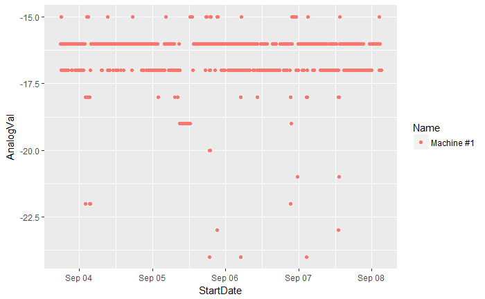

```r
# We will take one process for Machine #1 and visualize it...
DF_TEMP %>%
  filter(EventText == "Cutting Process, phase angle") %>%
  filter(Name == "Machine #1") %>%
  ggplot(aes(x = StartDate, y = AnalogVal, col = Name)) + geom_point()
```

##### Implement for one specific process of one machine

```r
# get only data for specific sub-process
DF_M1_Cut_Ph <- DF_TEMP %>%
  filter(EventText == "Cutting Process, phase angle") %>%
  filter(Name == "Machine #1") %>%
  select(StartDate, AnalogVal)
```

Now we are ready to transform our data to `xts object`

```r
# create xts object (matrix and index)
xts_M1_Cut_Ph <- as.xts(DF_M1_Cut_Ph[, -1], order.by = as.POSIXct(DF_M1_Cut_Ph$StartDate))
```

Some important quality checks is to check periocity of our data (e.g. seconds, minutes…)

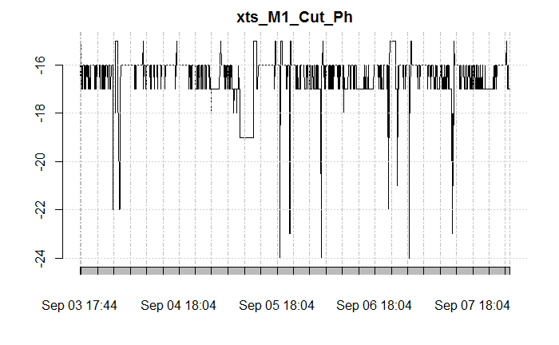

At this stage we can make apply some functions to the populations of the data during each hour. In this example it’s simple `mean`, `max`, `min`, `sd` or Standard Deviation…

```r
head(merge(AnalogVal_mean, AnalogVal_max, AnalogVal_Min, AnalogVal_sd))
```

```
                    AnalogVal_mean AnalogVal_max AnalogVal_Min AnalogVal_sd
2017-09-03 17:59:24      -16.25000           -16           -17    0.5000000
2017-09-03 18:59:24      -16.25000           -15           -17    0.6215816
2017-09-03 19:59:24      -16.41667           -16           -17    0.5149287
2017-09-03 20:59:24      -16.25000           -16           -17    0.4522670
2017-09-03 21:59:24      -16.25000           -16           -17    0.4522670
2017-09-03 22:59:24      -16.08333           -16           -17    0.2886751
```

We can of course merge and store these new columns in one `xts` object. We should not worry because `xts` will make sure our data rows are matching index [time]

```r
head(xts_CUT_Ph)
```

```
                    AnalogVal_mean AnalogVal_max AnalogVal_Min AnalogVal_sd
2017-09-03 17:59:24      -16.25000           -16           -17    0.5000000
2017-09-03 18:59:24      -16.25000           -15           -17    0.6215816
2017-09-03 19:59:24      -16.41667           -16           -17    0.5149287
2017-09-03 20:59:24      -16.25000           -16           -17    0.4522670
2017-09-03 21:59:24      -16.25000           -16           -17    0.4522670
2017-09-03 22:59:24      -16.08333           -16           -17    0.2886751
```

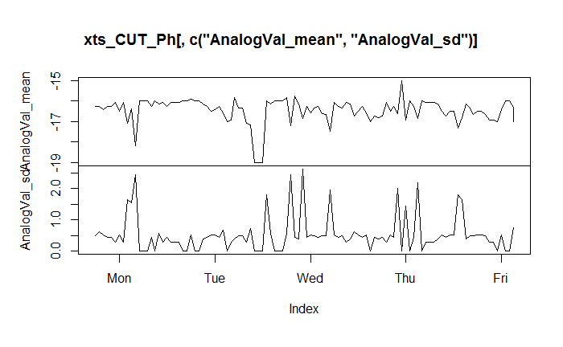

##### Returning back to DataFrame

It’s now possible to return to our original DataFrame

|  | AnalogVal_mean | AnalogVal_max | AnalogVal_Min | AnalogVal_sd | StartDate |
| --- | --- | --- | --- | --- | --- |
| 1 | -16.25000 | -16 | -17 | 0.5000000 | 2017-09-03 17:59:24 |
| 2 | -16.25000 | -15 | -17 | 0.6215816 | 2017-09-03 18:59:24 |
| 3 | -16.41667 | -16 | -17 | 0.5149287 | 2017-09-03 19:59:24 |
| 4 | -16.25000 | -16 | -17 | 0.4522670 | 2017-09-03 20:59:24 |
| 5 | -16.25000 | -16 | -17 | 0.4522670 | 2017-09-03 21:59:24 |
| 6 | -16.08333 | -16 | -17 | 0.2886751 | 2017-09-03 22:59:24 |

##### Turn this into function

```r
feature_eng_ts <- function(x, funcToApply = c("mean", "min", "max", "sd")){
  #function will return new dataframe with new features
  #x = dataframe with columns to perform feature engineering, it must contain data from one specific category
  #tscolname = column name containing time series data
  #avcolname - column name contining data to perform manipulations
  #funcToApply - vector containing functions to apply data transformations
  # convert to xts object
  DF_M1_xts <- as.xts(x[-1], order.by = as.POSIXct(x$StartDate))
  # aggregate by hour and create new features
  # convert periodicity from seconds to hours and apply some functions to create new features
  for(i in 1: length(funcToApply)){
    # apply functions and merge them
    res <- period.apply(DF_M1_xts, endpoints(DF_M1_xts, "hours"), funcToApply[i])
    names(res) <- paste("AnalogVal_", funcToApply[i], sep = "")
    # merge new features together
    if(i == 1){
      DF_M1_newfeatures <- res
      } else {
        DF_M1_newfeatures <- merge(DF_M1_newfeatures, res)
        }
  }
  # return to the dataframe
  DF_M1_NF <- coredata(DF_M1_newfeatures) %>% as.data.frame(row.names = F)
  DF_M1_NF$StartDate <- index(DF_M1_newfeatures)
  # return result
  return(DF_M1_NF)
}
```

##### Example of usage

Let’s try to see how to use our function…

```r
# we can apply transformation to each specific machine and each specific sub-process
DF <- DF_TEMP %>%
  filter(EventText == "Cutting Process, phase angle") %>%
  filter(Name == "Machine #1") %>%
  select(StartDate, AnalogVal)
# keep just categories of the data: machine and event text
DF_Cat <- DF_TEMP %>%
  filter(EventText == "Cutting Process, phase angle") %>%
  filter(Name == "Machine #1") %>% select(EventText, Name) %>% unique()
# get new dataset with new features
DF_FE <- feature_eng_ts(DF)
# join original categories
DF_FE$EventText <- DF_Cat[1,1]
DF_FE$Name <- DF_Cat[1,2]
# review obtained dataset
head(DF_FE)
```

|  | AnalogVal_mean | AnalogVal_min | AnalogVal_max | AnalogVal_sd | StartDate | EventText | Name |
| --- | --- | --- | --- | --- | --- | --- | --- |
| 1 | -16.25000 | -17 | -16 | 0.5000000 | 2017-09-03 17:59:24 | Cutting Process, phase angle | Machine #1 |
| 2 | -16.25000 | -17 | -15 | 0.6215816 | 2017-09-03 18:59:24 | Cutting Process, phase angle | Machine #1 |
| 3 | -16.41667 | -17 | -16 | 0.5149287 | 2017-09-03 19:59:24 | Cutting Process, phase angle | Machine #1 |
| 4 | -16.25000 | -17 | -16 | 0.4522670 | 2017-09-03 20:59:24 | Cutting Process, phase angle | Machine #1 |
| 5 | -16.25000 | -17 | -16 | 0.4522670 | 2017-09-03 21:59:24 | Cutting Process, phase angle | Machine #1 |
| 6 | -16.08333 | -17 | -16 | 0.2886751 | 2017-09-03 22:59:24 | Cutting Process, phase angle | Machine #1 |

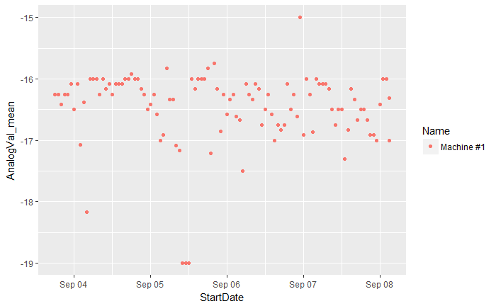

```r
# plot some variables
ggplot(DF_FE, aes(x = StartDate, y = AnalogVal_mean, col = Name)) + geom_point()
```

At the first look, we have probably obtained much better separation between normality / anormality… we will see how it will work in our `ShinyApp`…

#### Your turn… [practice]

Let’me suggest you to do some practical activity in order to ‘live’ the moment of feature engineering… Use R-Notebook and copy/paste code adapting for your specific needs to achieve the goal

- Try to create similar data transformation using function for another ‘Event’ for example ‘Tubing process resistance’.
- Try to change the function `feature_eng_ts` in a way that `mad()` function is added [Median Absolute Deviation]